# MyStudy Report

# 3 Methods

## 3.1 Study Design

The study used a longitudinal randomized controlled trial design with 2 groups (Treatment vs. Control) x 4 sites (A, B, C, and D) x 2 time points (pretest vs. posttest). Potential participants were recruited and screened for eligibility. Eligible individuals who consented to participate were enrolled, then given the pretest before being randomly assigned to either the treatment or control group. The treatment group then received a 9-week intervention intended to increase outcome scores. The control group did not receive any intervention. After the 9 week intervention period, both groups were given the posttest. The study design can be visualized with Shadish, Cook, & Campbell’s (2002) design notation, as shown in Table 1.

````markdown
```{r}
#| label: tbl-study-design
#| tbl-cap: MyStudy Experimental Research Design
#| results: asis

StudyDesign <- data.frame(Group = c("Treatment", "Control"),
                          Pretest = rep("$O_1$", times = 2),
                          Allocation = rep("$R$", times = 2),
                          Intervention = c("$X$", ""),
                          Posttest = rep("$O_2$", times = 2))

FN <- paste("The same design was used within each of 4 sites (A, B, C, & D).",
            "$O_i$, observed data at time $i$;",
            "$R$, randomized;",
            "$X$, delivery of intervention (9 weeks).")
kable(StudyDesign, format = "html", escape = FALSE, align = "lcccc") %>%
  kable_styling(full_width = FALSE) %>%
  add_header_above(c(" ", "Longitudinal Event" = 4), escape = FALSE) %>%
  footnote(general = FN, general_title = "Note: ", footnote_as_chunk = TRUE,
           threeparttable = FALSE, escape = FALSE) %>%
  cat()
```
````

Table 1: MyStudy Experimental Research Design

| Group | Longitudinal Event Pretest | Longitudinal Event Allocation | Longitudinal Event Intervention | Longitudinal Event Posttest |
| --- | --- | --- | --- | --- |
| Treatment | $O_1$ | $R$ | $X$ | $O_2$ |
| Control | $O_1$ | $R$ |  | $O_2$ |

Note: The same design was used within each of 4 sites (A, B, C, & D). $O_i$, observed data at time $i$; $R$, randomized; $X$, delivery of intervention (9 weeks).

**Tip**

Quarto allows you to automate numbering tables. Just give the chunk that generates a table a *unique* label with the prefix `tbl-` and then insert a [cross-reference](https://quarto.org/docs/authoring/tables.html#cross-references) into the script’s body text. The cross-reference for Table 1 is `@tbl-study-design`, which is just the label of the chunk prefixed by an `@` sign.

**Tip**

Suppose I want to show how many participants there are broken down by group and site as a means of further describing the study design. **Integrating a chunk of R code** into the document will **automate inserting** **its results** into the output. Here’s an example where I just use a pair of R functions to look at the relevant crosstab.

````markdown
```{r}
#| label: xtab-sample-size

MyStudy %>%
  xtabs(~Site + Group, data = .) %>%
  addmargins()
```
````

```
     Group
Site  Ctl Trt Sum
  A    20  20  40
  B    20  20  40
  C    20  20  40
  D    20  20  40
  Sum  80  80 160
```

The result is functional and accurate output that **preserves methodology** **details** (i.e., code). That might be sufficient if our only audience is going to be people who are used to reading raw R output, but with just a little more code, we can get a publication-quality result, as shown next.

Meanwhile, Table 2 shows the sample size by group and site.

````markdown
```{r}
#| label: tbl-sample-size
#| tbl-cap: Number of Participants by Group and Site
#| results: asis

FN = "This is fictional example data."

MyStudy %>%
  xtabs(~Site + Group, data = .) %>%
  addmargins() %>%
  kable(col.names = c("Site", "Control", "Treatment", "Sum")) %>%
  kable_styling(full_width = FALSE) %>%
  column_spec(column = 4, italic = TRUE) %>%
  row_spec(row = 5, italic = TRUE) %>%
  add_header_above(header = c(" ", "Group" = 2, " ")) %>%
  footnote(general = FN, general_title = "Note: ", footnote_as_chunk = TRUE) %>%
  cat()
```
````

Table 2: Number of Participants by Group and Site

| Site | Group Control | Group Treatment | Sum |
| --- | --- | --- | --- |
| A | 20 | 20 | 40 |
| B | 20 | 20 | 40 |
| C | 20 | 20 | 40 |
| D | 20 | 20 | 40 |
| Sum | 80 | 80 | 160 |

Note: This is fictional example data.

**Tip**

Notice that we have **automated** doing several things:

- Numbered the table via the `label:` Quarto chunk option.
- Added a meaningful caption via the `tbl-cap:` Quarto chunk option.
- Inserted the table number into the text above (as a hyperlink to the table itself) via a cross-reference.
- Added a column grouping header.
- Improved the column labels.
- Added a footnote.
- Formatted the sums with italics.

I used the [`knitr`](https://cran.r-project.org/package=knitr) and [`kableExtra`](https://cran.r-project.org/package=kableExtra) R packages to format Table 2. Consider how long it would take you to turn the raw result I showed first into table in a Word document, then format it like Table 2. Automating such formatting work can save you time. If the underlying data changes, we can update Table 2 just by re-rendering the script.

## 3.2 Measures

We have the following variables in the available dataset.

### 3.2.1 Participant ID (`PID`)

Each participant received a unique, sequential integer identification number.

### 3.2.2 Group (`Group`)

Group is a nominal categorical factor with levels of `Treatment` and `Control`, with `Control` as the reference level.

### 3.2.3 Recruitment Site (`Site`)

Site is a nominal, categorical factor with levels of `A`, `B`, `C`, `D`, with `A` serving as the reference level.

### 3.2.4 Outcome Scores (`Score_Pre` & `Score_Post`)

Outcome scores were measured twice with continuous scale scores, once at pretest and once at posttest, using the same instrument. High scores represent better outcomes for the participants than low scores. Based on prior research, we expect at least modest correlation between pretest and posttest scores over the 9-week duration of the study.

## 3.3 Statistical Analysis Plan

The main objective of MyStudy is to test whether the intervention increased posttest outcome scores after controlling for pretest scores and recruitment site. We can use an analysis of covariance (ANCOVA) where group, site, and pretest scores predict the outcome scores to do that (Vickers & Altman, 2001). A secondary objective is to test whether the sites differ with respect to outcomes. In the ANCOVA model, the group effect and associated contrast between the estimated marginal means for the two groups will directly allow us to examine the intervention effect (Vickers & Altman, 2001).

To improve interpretation of model parameters, we will use a mean-centered form of the pretest scores (i.e., the variable `Centered_Score_Pre` instead of `Score_Pre`) (Aiken & West, 1991).

````markdown
```{r}
#| label: check-contrasts-Group

# Default contrast coding for categorical factors.
contrasts(MyStudy$Group)
```
````

```
    Trt
Ctl   0
Trt   1
```

Next, we show the default contrast coding for site.

````markdown
```{r}
#| label: check-contrasts-Site

# Default contrast coding for categorical factors.
contrasts(MyStudy$Site)
```
````

```
  B C D
A 0 0 0
B 1 0 0
C 0 1 0
D 0 0 1
```

We change to effect coding then display the updated contrast codes in the next two chunks below.

````markdown
```{r}
#| label: set-effect-coding-Group

contrasts(MyStudy$Group) <- matrix(data = c(-1, 1),
                                   byrow = TRUE, nrow = 2, ncol = 1,
                                   dimnames = list(c("Ctl", "Trt"),
                                                   c("Treatment")))
contrasts(MyStudy$Group) # Updated
```
````

```
    Treatment
Ctl        -1
Trt         1
```

````markdown
```{r}
#| label: set-effect-coding-Site

contrasts(MyStudy$Site) <-   matrix(data = c(-1, -1, -1,
                                              1,  0,  0,
                                              0,  1,  0,
                                              0,  0,  1),
                                  byrow = TRUE, nrow = 4, ncol = 3,
                                  dimnames = list(c("A", "B", "C", "D"),
                                                  c("B", "C", "D")))
contrasts(MyStudy$Site) # Updated
```
````

```
   B  C  D
A -1 -1 -1
B  1  0  0
C  0  1  0
D  0  0  1
```

Note that contrast coding does not affect the Wald tests of individual parameters, the overall model fit, or Type II sums of squares (SS) tests for the significance of predictors. It does however change the value and meaning of the intercept and of parameter estimates associated with categorical factors (Schad et al., 2020). With effect coding for categorical factors, the intercept estimates the grand mean when continuous predictors are set to 0. Factor parameter estimates test whether the means of individual levels differ from the grand mean. Regardless of contrast coding, one can still obtain estimated marginal means for the levels of factors and perform contrasts between them.

To test for the effects of categorical factors with more than two levels (e.g., site), we will use Type II ANOVA tests (Hector et al., 2010; Langsrud, 2003). Because there are no interactions in the model, these can be interpreted as the main effect of the indicated predictor after controlling for the other predictors in the model. They would be valid even if there were unbalanced sample sizes across cells in the factorial design.

# 4 Results

The next chunk below fits the ANCOVA model.

````markdown
```{r}
#| label: fit-model

m0 <- lm(Score_Post ~ 1, data = MyStudy)
m1 <- lm(Score_Post ~ Centered_Score_Pre + Site + Group, data = MyStudy)
```
````

**Tip**

We could use the raw R output from a summary of the model, which would look like this:

````markdown
```{r}
#| label: raw-model-summary
summary(m1)
```
````

```
Call:
lm(formula = Score_Post ~ Centered_Score_Pre + Site + Group,
    data = MyStudy)

Residuals:
     Min       1Q   Median       3Q      Max
-22.4116  -5.9378   0.0021   6.5995  25.9707

Coefficients:
                   Estimate Std. Error t value Pr(>|t|)
(Intercept)        78.87903    0.71477 110.356  < 2e-16 ***
Centered_Score_Pre  0.15600    0.07507   2.078   0.0394 *
SiteB              -0.26017    1.24133  -0.210   0.8343
SiteC              -1.70122    1.26978  -1.340   0.1823
SiteD               0.95685    1.24042   0.771   0.4417
GroupTreatment      3.24831    0.71900   4.518 1.24e-05 ***
---
Signif. codes:  0 '***' 0.001 '**' 0.01 '*' 0.05 '.' 0.1 ' ' 1

Residual standard error: 9.041 on 154 degrees of freedom
Multiple R-squared:  0.1361,    Adjusted R-squared:  0.1081
F-statistic: 4.854 on 5 and 154 DF,  p-value: 0.0003763
```

But again, we can do something much more professional with a little more code, as shown below.

Table 3 shows the ANCOVA model parameters and corresponding confidence intervals, while Table 4 shows its model fit statistics.

````markdown
```{r}
#| label: tbl-m1-paramters
#| tbl-cap: Parameters for ANCOVA Model 1 for Posttest Scores
#| results: asis

FN = paste("Site reference is A, Group reference is Control;",
           "95% CIs reported.")

modelsummary(list("Model 1: Posttest Score" = m1), output = "kableExtra",
             align = "lrrrrr", escape = FALSE,
             fmt = fmt_decimal(digits = 2, pdigits = 3),
             col.names = c("Term", "Est.", "CI.LL", "CI.UL", "t", "p"),
             shape = term ~ model + statistic,
             statistic = c("conf.int", "statistic", "p.value"),
             coef_rename = c("Intercept", "Centered Pretest Score", "Site: B",
                             "Site: C", "Site: D", "Group: Treatment"),
             gof_map = "nobs", notes = FN) %>%
  cat()
```
````

Table 3: Parameters for ANCOVA Model 1 for Posttest Scores

| Term | Model 1: Posttest Score Est. | Model 1: Posttest Score CI.LL | Model 1: Posttest Score CI.UL | Model 1: Posttest Score t | Model 1: Posttest Score p |
| --- | --- | --- | --- | --- | --- |
| Intercept | 78.88 | 77.47 | 80.29 | 110.36 | <0.001 |
| Centered Pretest Score | 0.16 | 0.01 | 0.30 | 2.08 | 0.039 |
| Site: B | −0.26 | −2.71 | 2.19 | −0.21 | 0.834 |
| Site: C | −1.70 | −4.21 | 0.81 | −1.34 | 0.182 |
| Site: D | 0.96 | −1.49 | 3.41 | 0.77 | 0.442 |
| Group: Treatment | 3.25 | 1.83 | 4.67 | 4.52 | <0.001 |
| Num.Obs. | 160 |  |  |  |  |

Site reference is A, Group reference is Control; 95% CIs reported.

````markdown
```{r}
#| label: tbl-m1-fit
#| tbl-cap: Fit Statistics for ANCOVA Model 1 for Posttest Scores
#| results: asis

glance(m1) %>%
  select("sigma", "r.squared", "adj.r.squared", "logLik", "deviance",
         "AIC", "BIC", "statistic", "df", "df.residual", "p.value") %>%
  kable(., format = "html", digits = c(2, 2, 2, 2, 2, 2, 2, 2, 0, 0, 6),
        escape = TRUE,
        col.names = c("Sigma", "$R^2$", "Adj. $R^2$", "LL", "Deviance",
                      "AIC", "BIC", "F", "df1", "df2", "p")) %>%
  kable_styling() %>%
  cat()
```
````

Table 4: Fit Statistics for ANCOVA Model 1 for Posttest Scores

| Sigma | $R^2$ | Adj. $R^2$ | LL | Deviance | AIC | BIC | F | df1 | df2 | p |
| --- | --- | --- | --- | --- | --- | --- | --- | --- | --- | --- |
| 9.04 | 0.14 | 0.11 | -576.26 | 12588.55 | 1166.52 | 1188.05 | 4.85 | 5 | 154 | 0.000376 |

We can see from the Type II ANOVA tests (Hector et al., 2010; Langsrud, 2003) in Table 5 that there is no compelling evidence of a site main effect after controlling for other predictors in the model, but there is a group effect.

**Tip**

I used the [`modelsummary`](https://cran.r-project.org/package=modelsummary) R package to automate formatting Table 3 and the [`broom`](https://cran.r-project.org/package=broom), [`knitr`](https://cran.r-project.org/package=knitr) and [`kableExtra`](https://cran.r-project.org/package=kableExtra) R packages to format Table 4.

````markdown
```{r}
#| label: tbl-m1-anova
#| tbl-cap: ANOVA Tests of Predictor Main Effects on Posttest Scores
#| results: asis

FN = paste("Site reference is A, Group reference is Control;",
           "95% CIs reported.")

# Same result regardless of contrast coding
Anova(mod = m1, type = 2) %>%
  tidy() %>%
  mutate(term = if_else(term == "Centered_Score_Pre",
                        true = "Centered Pretest Score",
                        false = term)) %>%
  kable(., format = "html", digits = c(0, 2, 0, 2, 5),
        col.names = c("Term", "Type II SS", "df", "F", "p")) %>%
  kable_styling(full_width = FALSE) %>%
  cat()
```
````

Table 5: ANOVA Tests of Predictor Main Effects on Posttest Scores

| Term | Type II SS | df | F | p |
| --- | --- | --- | --- | --- |
| Centered Pretest Score | 353.01 | 1 | 4.32 | 0.03936 |
| Site | 187.71 | 3 | 0.77 | 0.51506 |
| Group | 1668.45 | 1 | 20.41 | 0.00001 |
| Residuals | 12588.55 | 154 | NA | NA |

**Tip**

I used the [`car`](https://cran.r-project.org/package=car) R package to get the analysis in Table 5 and the [`broom`](https://cran.r-project.org/package=broom), [`knitr`](https://cran.r-project.org/package=knitr) and [`kableExtra`](https://cran.r-project.org/package=kableExtra) R packages to format it.

To further examine the results, we estimated the estimated marginal means for each group (see Table 6) and visualize the result in Figure 1, where the lack of overlap between the red arrows indicates a significant difference. The unstandardized effect size for the group effect is shown in Table 7. We can see that the treatment did indeed improve posttest scores as intended.

````markdown
```{r}
#| label: tbl-emm-Group
#| tbl-cap: Estimated Marginal Means for Posttest Scores by Group from Model 1
#| results: asis

emm_Group <- emmeans(m1, ~ Group)

# Table footnote.
FN <- "Results are averaged over the levels of site."

emm_Group %>%
  as_tibble(.) %>%
  rename(Mean = emmean, LL= lower.CL, UL= upper.CL) %>%
  mutate(Group = factor(Group, levels = c("Ctl", "Trt"),
                        labels = c("Control", "Treatment"))) %>%
  kable(., format = "html", digits = 2) %>%
  kable_styling(full_width = FALSE) %>%
  add_header_above(header = c(" " = 4, "95% CI" = 2)) %>%
  footnote(general = FN, general_title = "Note: ", footnote_as_chunk = TRUE) %>%
  cat()
```
````

Table 6: Estimated Marginal Means for Posttest Scores by Group from Model 1

| Group | Mean | SE | df | 95% CI LL | 95% CI UL |
| --- | --- | --- | --- | --- | --- |
| Control | 75.63 | 1.01 | 154 | 73.63 | 77.63 |
| Treatment | 82.13 | 1.01 | 154 | 80.12 | 84.13 |

Note: Results are averaged over the levels of site.

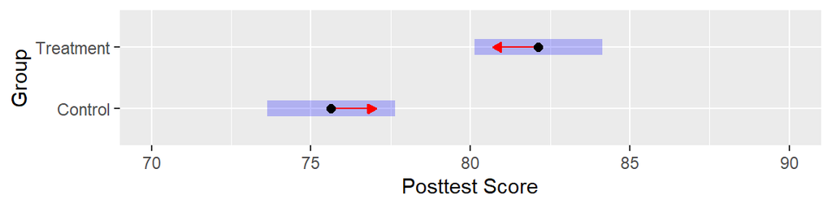

Figure 1: Estimated Marginal Means for Posttest Scores by Group from Model 1

````markdown
```{r}
#| label: fig-emm-Group
#| fig-cap: Estimated Marginal Means for Posttest Scores by Group from Model 1
#| fig-height: 1.5
#| fig-width: 6

plot(emm_Group, comparisons = TRUE, xlab = "Posttest Score") +
  scale_x_continuous(limits = c(70, 90),
                     breaks = seq(from = 70, to = 90, by = 5)) +
  scale_y_discrete(labels = c("Control", "Treatment"))
```
````

````markdown
```{r}
#| label:  tbl-emm-Group-difftest
#| tbl-cap: "Unstandardized Effect Size for Differences Between Group Means"
#| results: asis

# Table footnote.
FN <- "Estimates are in the units of the posttest scores."

pairwise_diff <- pairs(emm_Group, adjust = "none", reverse = TRUE) %>%
  summary(., infer = c(TRUE, FALSE), level = 0.95) %>%
  mutate(contrast = "Treatment -  Control") %>%
  select(contrast, estimate, SE, df, lower.CL, upper.CL)

pairwise_diff %>%
  kable(., format = "html", digits = 2,
      col.names = c("Comparison", "Estimate", "SE", "df", "LL", "UL")) %>%
  kable_styling(full_width = FALSE) %>%
  add_header_above(header = c(" " = 4, "95% CI" = 2)) %>%
  footnote(., general = FN, threeparttable = TRUE, footnote_as_chunk=TRUE,
           general_title = "Notes.") %>%
  cat()
```
````

Table 7: Unstandardized Effect Size for Differences Between Group Means

| Comparison | Estimate | SE | df | 95% CI LL | 95% CI UL |
| --- | --- | --- | --- | --- | --- |
| Treatment - Control | 6.5 | 1.44 | 154 | 3.66 | 9.34 |

Notes. Estimates are in the units of the posttest scores.

**Tip**

I used the [`emmeans`](https://cran.r-project.org/package=emmeans) R package to get the estimated marginal means and the [`knitr`](https://cran.r-project.org/package=knitr) and [`kableExtra`](https://cran.r-project.org/package=kableExtra) R packages to format Table 6 and Table 7, plus the [`ggplot2`](https://cran.r-project.org/package=ggplot2) R package to format Figure 1.

# 5 References

Aiken, L. S., & West, S. G. (1991). *Multiple regression: Testing and interpreting interactions*. Sage Publications, Inc.

American Psychological Association. (2020). *Publication manual of the american psychological association* (7th ed.). Author.

Hector, A., Von Felten, S., & Schmid, B. (2010). Analysis of variance with unbalanced data: An update for ecology & evolution. *Journal of Animal Ecology*, *79*(2), 308–316. https://doi.org/10.1111/j.1365-2656.2009.01634.x

Langsrud, Ø. (2003). ANOVA for unbalanced data: Use type II instead of type III sums of squares. *Statistics and Computing*, *13*(2), 163–167. https://doi.org/10.1023/A:1023260610025

Pierce, S. J. (2025, March 6). *Reproducible research: Principles, practices, and tools for generating reproducible statistical analyses and reports* [Online seminar]. Center for Statistical Training and Consulting webinar series on Responsible and Ethical Conduct of Research, East Lansing, MI, United States. https://github.com/sjpierce/CSTAT.RR2025

Schad, D. J., Vasishth, S., Hohenstein, S., & Kliegl, R. (2020). How to capitalize on a priori contrasts in linear (mixed) models: A tutorial. *Journal of Memory and Language*, *110*. https://doi.org/10.1016/j.jml.2019.104038

Shadish, W. R., Cook, T. D., & Campbell, D. T. (2002). *Experimental and quasi-experimental designs for generalized causal inference*. Houghton Mifflin Company.

Vickers, A. J., & Altman, D. G. (2001). Analysing controlled clinical trials with baseline and follow-up measurements. *British Medical Journal*, *323*(7321), 1123–1124. https://doi.org/10.1136/bmj.323.7321.1123

**Tip**

**Quarto automated integrating formatted in-text citations and a formatted** **reference list** because I added the following lines to the YAML header for this script:

```
bibliography: references.bib
csl: apa.csl
```

The first line tells Quarto that the citation data used to construct the reference list entries above is in the `references.bib` file, while the second line tells Quarto to use the formatting rules in `apa.csl` when creating the list. Those are the American Psychological Association (2020) rules.

Individual entries are added to the list by inserting [citations](https://quarto.org/docs/authoring/citations.html) into the script that identify specific blocks of data in `references.bib`. For example, inserting the cross-reference `@APA-RN4003` in the prior paragraph inserted an item into the list, and the formatted in-text citation into the paragraph when I rendered the document.

Quarto inserts the final reference list wherever it finds the following bit of text, which I put under the References heading:

```
::: {#refs}
:::
```

# 6 Software Information

This section shows information about the current software environment.

**Tip**

This is part of meeting the **documentation criterion** for reproducibility by applying the **preservation, automation, and integration principles**: We are automating the process of preserving a description of the software used when rendering the document by integrating code that inserts that information below. This facilitates troubleshooting reproducibility issues if someone else is unable to get the same results I did from the same code. Start by checking whether they are using different versions of various packages.

We used [R](https://www.r-project.org/) as our main computing environment and [Quarto](https://quarto.org/) scripts to enhance reproducibility. We used RStudio as the editor to interface with R and Quarto.

- Software chain: **qmd file > RStudio > Quarto > R > knitr > md file > Pandoc > HTML file**.
- Source file: **MyStudy_Report.qmd**
- Output file: **output/MyStudy_Report.html**
- [Quarto 1.7.13](https://quarto.org/) runs `*.qmd` files through [R](https://www.r-project.org/) and [knitr](https://yihui.org/knitr/) to produce `*.md` markdown files.
- [Pandoc 3.2](https://pandoc.org) converts markdown files (`*.md`) to other formats, including LaTeX (`*.tex`) and HTML (`*.html`) among others.

**Tip**

Following the **separation principle**, the source code for this report is stored in one file, but the rendered output will be put in a different file in another subfolder.

I used [inline R code](https://quarto.org/docs/computations/inline-code.html) above to dynamically insert the filenames based on paramter values in the source script’s YAML header. The inline R code looks like this:

```
- Source file: **`{r} paste0(params$SourceDir, params$SourceFile)`**
- Output file: **`{r} paste0(params$SourceDir, "output/", params$LogFile)`**
```

## 6.1 Versions

This document was generated using the following computational environment and dependencies:

````markdown
```{r}
#| label: show-version

# Get R and R package version numbers in use.
```
````

[output not shown]

## 6.2 Git Details

The current Git commit details and status are:

```r
git_report()
```

```
Local:    main C:/Users/pierces1/OneDrive - Michigan State University/CSTATRedirects/Documents/Professional/Presentations/CSTAT.RR2025
Remote:   main @ origin (https://github.com/sjpierce/CSTAT.RR2025.git)
Head:     [b68cdfd] 2025-03-05: Updated R release year. Re-rendered scripts.
```

```
Untracked files:
    Untracked:  Create_MyStudy_Data.html
    Untracked:  MyStudy_Report.rmarkdown
    Untracked:  MyStudy_Report_files/
    Untracked:  Slides.html
```

This is useful because it tells us exactly which commit in the Git history we would need to be using to make sure we are running the exact same code. Sometimes another person is not using the most current code, or has changed the code in some way since it was last committed.

**Tip**

Untracked files are files located in the repository that Git has not been told to entirely ignore, but have also not been commited into the version history.

Unstaged changes to files indicate that some of the contents have been modified since the last time the file was committed to Git. For a final production run of a report, you want the Git output to not show any unstaged changes to key files!